# seaborn 실습2

```python
import pandas as pd
import numpy as np
import matplotlib.pyplot as plt
import seaborn as sns
```

```python
# warning 무시
import warnings
warnings.filterwarnings('ignore')
```

```python
import matplotlib.pylab as plt
# '-' 깨짐 해결 모듈
import matplotlib as mpl

plt.rcParams["font.family"] = "Malgun Gothic"  # For Windows
plt.rcParams["font.size"] = 12
plt.rcParams["figure.figsize"] = (12, 6)
print(plt.rcParams["font.family"])

# 마이너스 깨짐 해결
mpl.rcParams["axes.unicode_minus"] = False
```

```
['Malgun Gothic']
```

## 통계 기반의 시각화를 제공해주는 Seaborn

`seaborn` 라이브러리가 매력적인 이유는 바로 **통계 차트** 입니다.

이번 실습에서는 `seaborn`의 다양한 통계 차트 중 대표적인 차트 몇 개를 뽑아서 다뤄볼 예정입니다.

더 많은 통계 차트를 경험해보고 싶으신 분은 [공식 도큐먼트](https://seaborn.pydata.org/api.html)에서 확인하실 수 있습니다.

```python
titanic = sns.load_dataset('titanic')
titanic
```

|  | survived | pclass | sex | age | sibsp | parch | fare | embarked | class | who | adult_male | deck | embark_town | alive | alone |
| --- | --- | --- | --- | --- | --- | --- | --- | --- | --- | --- | --- | --- | --- | --- | --- |
| 0 | 0 | 3 | male | 22.0 | 1 | 0 | 7.2500 | S | Third | man | True | NaN | Southampton | no | False |
| 1 | 1 | 1 | female | 38.0 | 1 | 0 | 71.2833 | C | First | woman | False | C | Cherbourg | yes | False |
| 2 | 1 | 3 | female | 26.0 | 0 | 0 | 7.9250 | S | Third | woman | False | NaN | Southampton | yes | True |
| 3 | 1 | 1 | female | 35.0 | 1 | 0 | 53.1000 | S | First | woman | False | C | Southampton | yes | False |
| 4 | 0 | 3 | male | 35.0 | 0 | 0 | 8.0500 | S | Third | man | True | NaN | Southampton | no | True |
| ... | ... | ... | ... | ... | ... | ... | ... | ... | ... | ... | ... | ... | ... | ... | ... |
| 886 | 0 | 2 | male | 27.0 | 0 | 0 | 13.0000 | S | Second | man | True | NaN | Southampton | no | True |
| 887 | 1 | 1 | female | 19.0 | 0 | 0 | 30.0000 | S | First | woman | False | B | Southampton | yes | True |
| 888 | 0 | 3 | female | NaN | 1 | 2 | 23.4500 | S | Third | woman | False | NaN | Southampton | no | False |
| 889 | 1 | 1 | male | 26.0 | 0 | 0 | 30.0000 | C | First | man | True | C | Cherbourg | yes | True |
| 890 | 0 | 3 | male | 32.0 | 0 | 0 | 7.7500 | Q | Third | man | True | NaN | Queenstown | no | True |

891 rows × 15 columns

- survived: 생존여부
- pclass: 좌석등급
- sex: 성별
- age: 나이
- sibsp: 형제자매 + 배우자 숫자
- parch: 부모자식 숫자
- fare: 요금
- embarked: 탑승 항구
- class: 좌석등급 (영문)
- who: 사람 구분
- deck: 데크
- embark_town: 탑승 항구 (영문)
- alive: 생존여부 (영문)
- alone: 혼자인지 여부

```python
# tips = sns.load_dataset('tips')
file_path = "datas/sns_tips.csv"
tips = pd.read_csv(file_path)
tips
```

|  | total_bill | tip | gender | smoker | day | time | size |
| --- | --- | --- | --- | --- | --- | --- | --- |
| 0 | 16.99 | 1.01 | Female | No | Sun | Dinner | 2 |
| 1 | 10.34 | 1.66 | Male | No | Sun | Dinner | 3 |
| 2 | 21.01 | 3.50 | Male | No | Sun | Dinner | 3 |
| 3 | 23.68 | 3.31 | Male | No | Sun | Dinner | 2 |
| 4 | 24.59 | 3.61 | Female | No | Sun | Dinner | 4 |
| ... | ... | ... | ... | ... | ... | ... | ... |
| 239 | 29.03 | 5.92 | Male | No | Sat | Dinner | 3 |
| 240 | 27.18 | 2.00 | Female | Yes | Sat | Dinner | 2 |
| 241 | 22.67 | 2.00 | Male | Yes | Sat | Dinner | 2 |
| 242 | 17.82 | 1.75 | Male | No | Sat | Dinner | 2 |
| 243 | 18.78 | 3.00 | Female | No | Thur | Dinner | 2 |

244 rows × 7 columns

## 1. Countplot

항목별 갯수를 세어주는 `countplot` 입니다.

알아서 해당 column을 구성하고 있는 value들을 구분하여 보여줍니다.

[countplot 공식 도큐먼트](https://seaborn.pydata.org/generated/seaborn.countplot.html)

```python
# 배경을 darkgrid 로 설정
sns.set(style='darkgrid')
```

### 1-1 세로로 그리기

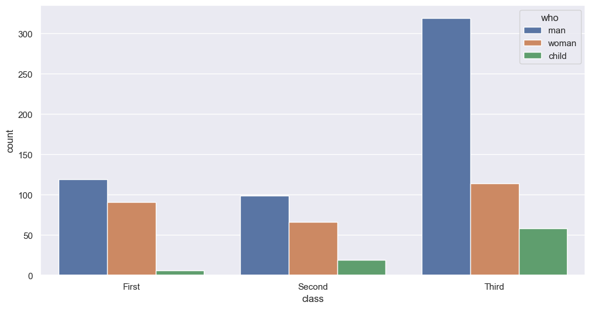

```python
sns.countplot(x="class", hue="who", data=titanic)
plt.show()
```

### 1-2. 가로로 그리기

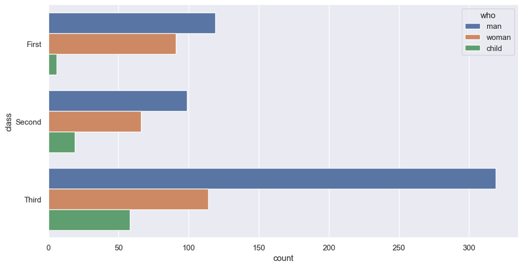

```python
sns.countplot(y="class", hue="who", data=titanic)
plt.show()
```

### 1-3. 색상 팔레트 설정

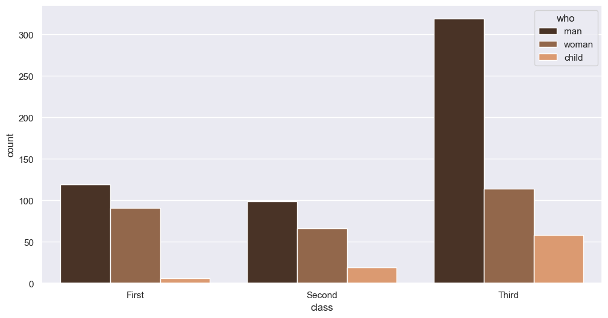

```python
sns.countplot(x="class", hue="who", palette='copper', data=titanic)
plt.show()
```

## 2. distplot

matplotlib의 `hist` 그래프와 `kdeplot`을 통합한 그래프 입니다.

**분포**와 **밀도**를 확인할 수 있음

[distplot 도큐먼트](https://seaborn.pydata.org/generated/seaborn.distplot.html?highlight=distplot#seaborn.distplot)

### distplot 전달인자

- 데이터의 분포를 시각화하여 데이터의 특성과 패턴을 파악하는 데 유용함
- rug : 데이터의 각 관측치를 축 위에 작은 선분으로 표시, 기본값 False
- hist : 히스토그램을 표시할지 여부를 결정, 기본값 True
- kde : 커널 밀도 추정(KDE)을 사용하여 곡선을 플롯에 추가, 기본값 True
- bins : 히스토그램의 빈(bin) 개수를 설정, 기본값은 'auto'

```python
# 샘플데이터 생성
x = np.random.randn(100)
x
```

```
array([-0.29994533, -0.2132505 , -0.59218714,  1.15332485, -0.40124503,
        1.34845009,  0.28051309, -0.34872084,  1.32580859,  1.1698292 ,
       -0.82458098,  0.93658261, -0.27225454, -2.07891654, -0.63020288,
       -0.11080658,  1.60101001, -0.49082322,  0.86795297,  0.5728473 ,
       -2.01790222,  0.47983472, -1.98955264, -0.49001525, -0.11103868,
       -0.53397952, -0.2772401 , -2.45558438, -0.21640007,  0.67158418,
       -0.53488658,  1.06037586,  0.34373028, -0.22542401, -0.76771507,
        0.2515963 ,  0.44100658,  0.41512683,  0.02895905,  0.56308003,
        0.07804309,  1.2702783 ,  0.67782869,  0.13318019,  1.28131349,
        0.3235033 , -0.55906903, -0.06632078,  0.01738905, -1.48674272,
       -0.35258143,  1.25003323,  0.55586443, -0.84560718, -1.98987052,
        1.08350005,  0.63094658,  0.58283563, -0.51389214, -0.27742815,
       -0.59445949, -1.43308912, -1.15907091, -1.4365865 , -1.76948305,
       -0.54528495, -0.4488171 ,  0.28306345,  0.90003612, -0.89318021,
       -0.32500109, -0.39331214,  0.91767418,  0.12824572, -1.85260317,
        1.48328015, -1.22813324, -0.25303083, -0.30335495,  0.84769864,
        0.8153534 , -0.62692572,  0.06063857,  0.56963757, -0.23488664,
        1.42553165, -0.71130082, -2.04505757,  0.37588366,  0.81236061,
        0.56445387,  0.84975232, -0.50800001, -1.01199156,  0.1060297 ,
        0.60198155, -0.45440998,  1.1917891 , -0.81838962, -0.5843293 ])
```

### 2-1. 기본 distplot

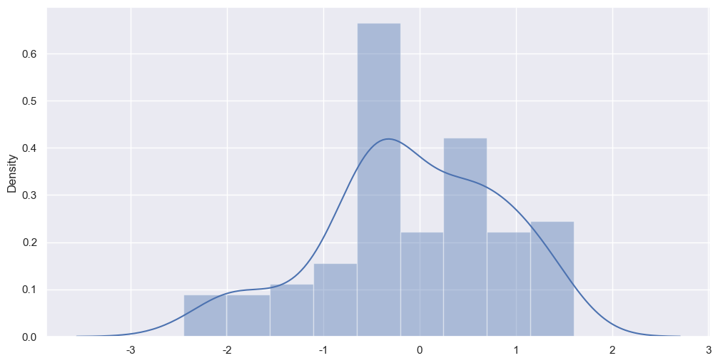

```python
sns.distplot(x)
plt.show()
```

### 2-2. 데이터가 Series 일 경우

```python
x = pd.Series(x, name="x variable")
x
```

```
0    -0.299945
1    -0.213251
2    -0.592187
3     1.153325
4    -0.401245
        ...
95    0.601982
96   -0.454410
97    1.191789
98   -0.818390
99   -0.584329
Name: x variable, Length: 100, dtype: float64
```

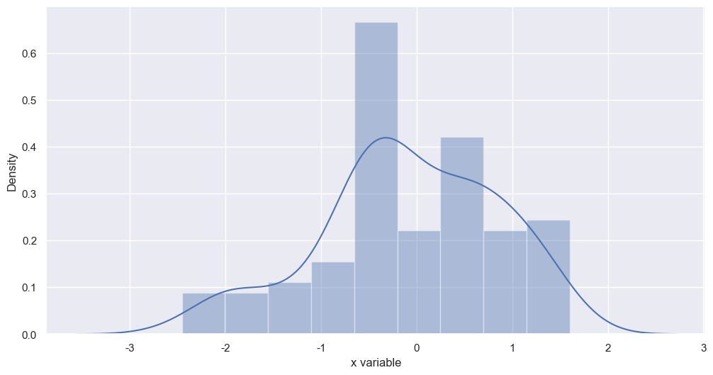

```python
sns.distplot(x)
plt.show()
```

### 2-3 rugplot

rug : 데이터의 각 관측치를 축 위헤 작은 선분으로 표시, 기본 False

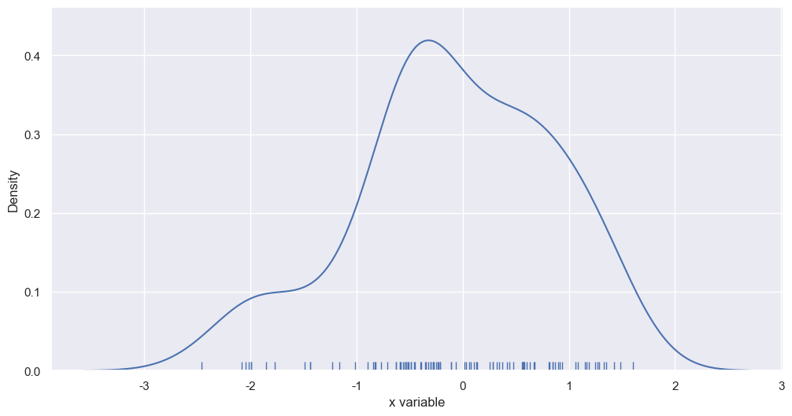

```python
sns.distplot(x, rug=True, hist=False, kde=True)
plt.show()
```

### 2-4. kde (kernel density)

`kde`는 histogram보다 **부드러운 형태의 분포 곡선**을 보여주는 방법

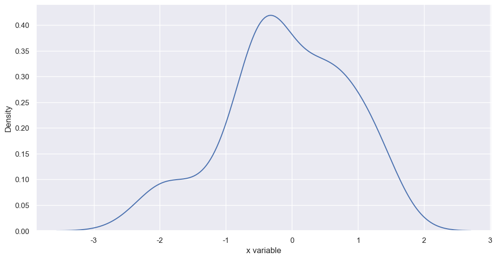

```python
sns.distplot(x, rug=False, hist=False, kde=True)
plt.show()
```

### 2-5. 가로로 표현하기

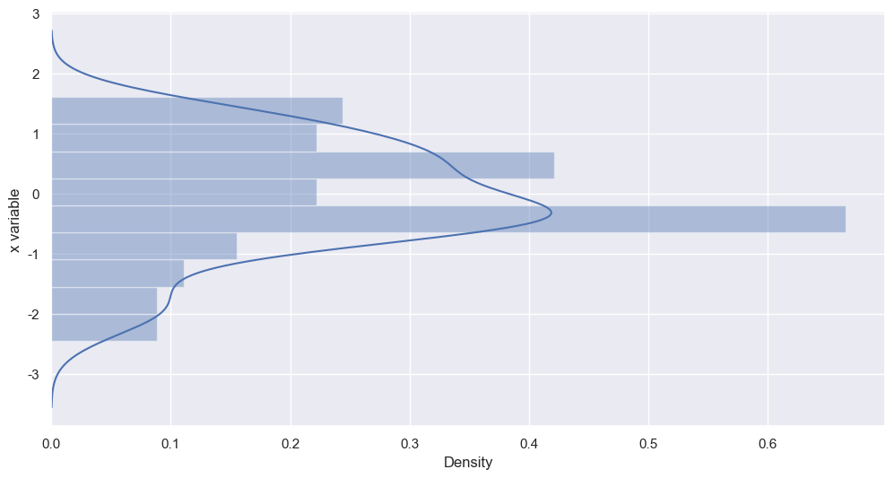

```python
 sns.distplot(x, vertical=True)
```

### 2-6. 컬러 바꾸기

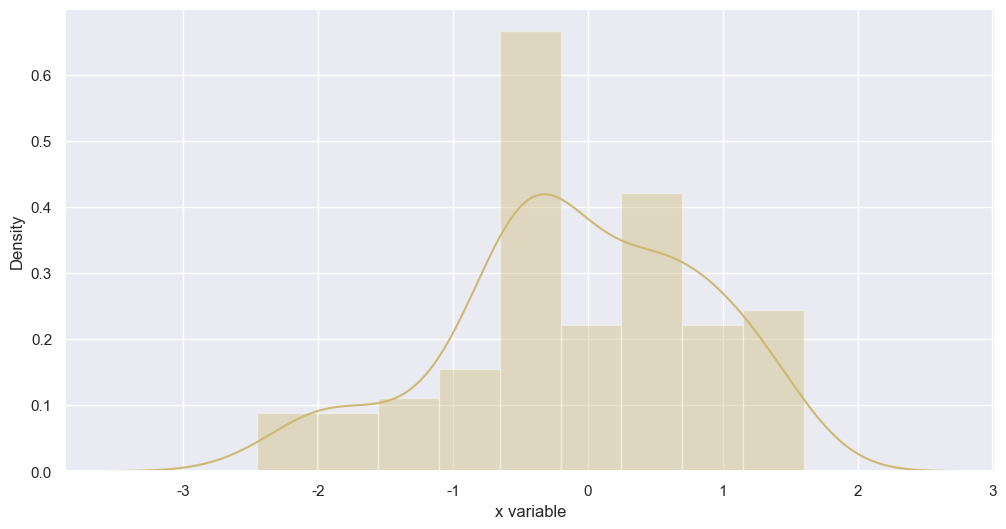

```python
sns.distplot(x, color="y")
plt.show()
```

## 3. heatmap

색상으로 표현할 수 있는 다양한 정보를 **일정한 이미지위에 열분포 형태의 비쥬얼한 그래픽**으로 출력하는 것이 특징이다

[heatmap 도큐먼트](https://seaborn.pydata.org/generated/seaborn.heatmap.html?highlight=heatmap#seaborn.heatmap)

### 3-1. 기본 heatmap

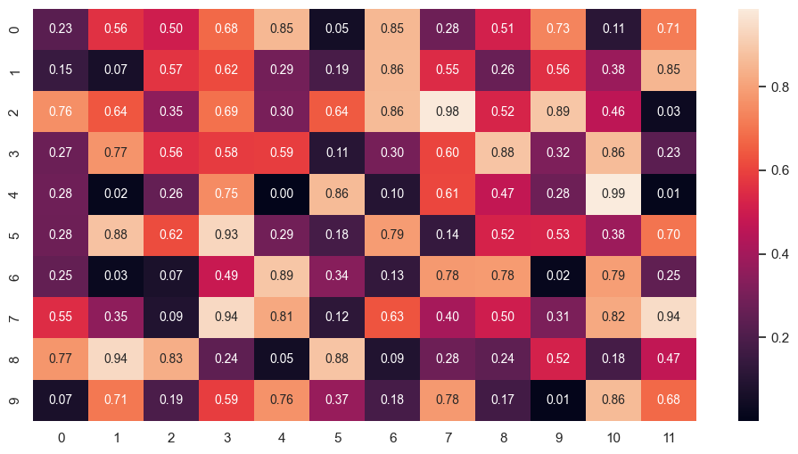

```python
uniform_data = np.random.rand(10, 12)
sns.heatmap(uniform_data, annot=True, fmt=".2f", annot_kws={"size": 10})
plt.show()
```

### 3-2. pivot table을 활용하여 그리기

sns_tips.csv 데이터 설명

- total_bill : 테이블의 전체 지불 금액
- tip : 팁으로 낸 금액
- gender : 웨이터의 성별
- smoker : 손님의 흡연 여부
- day : 요일
- time : 시간
- size : 테이블 인원수

```python
file_path = "datas/sns_tips.csv"
tips = pd.read_csv(file_path)
tips.head()
```

|  | total_bill | tip | gender | smoker | day | time | size |
| --- | --- | --- | --- | --- | --- | --- | --- |
| 0 | 16.99 | 1.01 | Female | No | Sun | Dinner | 2 |
| 1 | 10.34 | 1.66 | Male | No | Sun | Dinner | 3 |
| 2 | 21.01 | 3.50 | Male | No | Sun | Dinner | 3 |
| 3 | 23.68 | 3.31 | Male | No | Sun | Dinner | 2 |
| 4 | 24.59 | 3.61 | Female | No | Sun | Dinner | 4 |

```python
pivot = tips.pivot_table(index='day', columns='size', values='tip')
pivot
```

| size day | 1 | 2 | 3 | 4 | 5 | 6 |
| --- | --- | --- | --- | --- | --- | --- |
| Fri | 1.92 | 2.644375 | 3.000000 | 4.730000 | NaN | NaN |
| Sat | 1.00 | 2.517547 | 3.797778 | 4.123846 | 3.000000 | NaN |
| Sun | NaN | 2.816923 | 3.120667 | 4.087778 | 4.046667 | 5.0 |
| Thur | 1.83 | 2.442500 | 2.692500 | 4.218000 | 5.000000 | 5.3 |

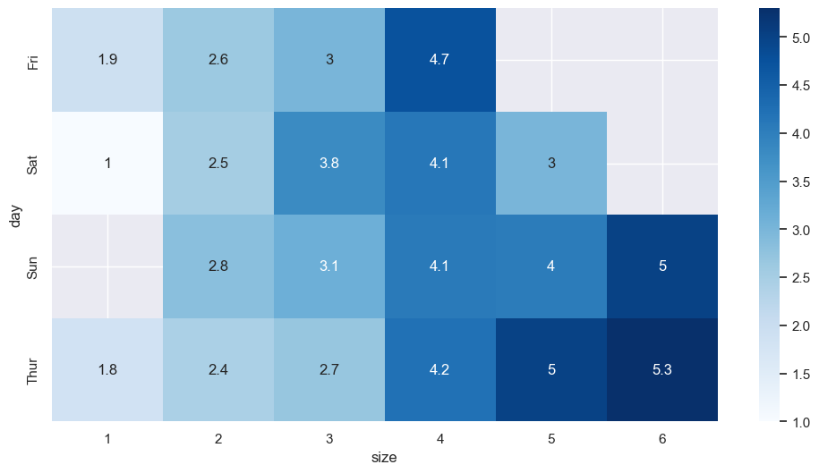

```python
sns.heatmap(pivot, cmap='Blues', annot=True)
plt.show()
```

### 3-3. correlation(상관관계)를 시각화

**corr()** 함수는 데이터의 상관관계를 보여줌

```python
# 숫자 컬럼만 추출하여 상관계수 계산
titanic.select_dtypes(include='number').corr()
```

|  | survived | pclass | age | sibsp | parch | fare |
| --- | --- | --- | --- | --- | --- | --- |
| survived | 1.000000 | -0.338481 | -0.077221 | -0.035322 | 0.081629 | 0.257307 |
| pclass | -0.338481 | 1.000000 | -0.369226 | 0.083081 | 0.018443 | -0.549500 |
| age | -0.077221 | -0.369226 | 1.000000 | -0.308247 | -0.189119 | 0.096067 |
| sibsp | -0.035322 | 0.083081 | -0.308247 | 1.000000 | 0.414838 | 0.159651 |
| parch | 0.081629 | 0.018443 | -0.189119 | 0.414838 | 1.000000 | 0.216225 |
| fare | 0.257307 | -0.549500 | 0.096067 | 0.159651 | 0.216225 | 1.000000 |

```python
# 범주형 변수 제외
num_columns = titanic.select_dtypes(include=['int64', 'float64']).columns
titanic[num_columns].head()
```

|  | survived | pclass | age | sibsp | parch | fare |
| --- | --- | --- | --- | --- | --- | --- |
| 0 | 0 | 3 | 22.0 | 1 | 0 | 7.2500 |
| 1 | 1 | 1 | 38.0 | 1 | 0 | 71.2833 |
| 2 | 1 | 3 | 26.0 | 0 | 0 | 7.9250 |
| 3 | 1 | 1 | 35.0 | 1 | 0 | 53.1000 |
| 4 | 0 | 3 | 35.0 | 0 | 0 | 8.0500 |

```python
# 상관관계 계수 구하기
corr_matrix = titanic[num_columns].corr()
```

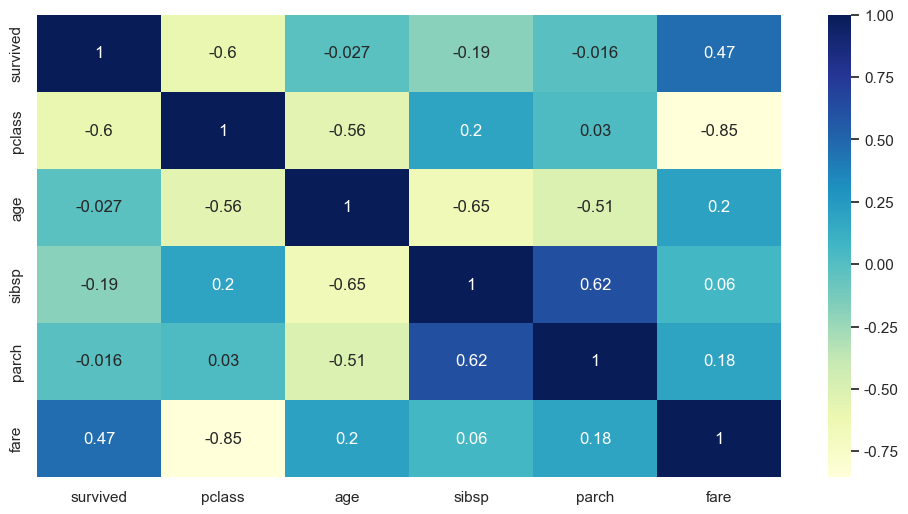

```python
sns.heatmap(corr_matrix.corr(), annot=True, cmap="YlGnBu")
plt.show()
```

### 범주형 데이터 label encoding 하기

- 설치 : pip install -U scikit-learn

```python
titanic_cp = titanic.copy()
titanic_cp.head()
```

|  | survived | pclass | sex | age | sibsp | parch | fare | embarked | class | who | adult_male | deck | embark_town | alive | alone |
| --- | --- | --- | --- | --- | --- | --- | --- | --- | --- | --- | --- | --- | --- | --- | --- |
| 0 | 0 | 3 | male | 22.0 | 1 | 0 | 7.2500 | S | Third | man | True | NaN | Southampton | no | False |
| 1 | 1 | 1 | female | 38.0 | 1 | 0 | 71.2833 | C | First | woman | False | C | Cherbourg | yes | False |
| 2 | 1 | 3 | female | 26.0 | 0 | 0 | 7.9250 | S | Third | woman | False | NaN | Southampton | yes | True |
| 3 | 1 | 1 | female | 35.0 | 1 | 0 | 53.1000 | S | First | woman | False | C | Southampton | yes | False |
| 4 | 0 | 3 | male | 35.0 | 0 | 0 | 8.0500 | S | Third | man | True | NaN | Southampton | no | True |

```python
titanic_cp['who'].value_counts()
```

```
who
man      537
woman    271
child     83
Name: count, dtype: int64
```

```python
# 중복 컬럼 삭제
titanic_cp = titanic_cp.drop(titanic_cp[['alive', 'adult_male', 'embark_town']], axis=1)
```

```python
titanic_cp.head()
```

|  | survived | pclass | sex | age | sibsp | parch | fare | embarked | class | who | deck | alone |
| --- | --- | --- | --- | --- | --- | --- | --- | --- | --- | --- | --- | --- |
| 0 | 0 | 3 | male | 22.0 | 1 | 0 | 7.2500 | S | Third | man | NaN | False |
| 1 | 1 | 1 | female | 38.0 | 1 | 0 | 71.2833 | C | First | woman | C | False |
| 2 | 1 | 3 | female | 26.0 | 0 | 0 | 7.9250 | S | Third | woman | NaN | True |
| 3 | 1 | 1 | female | 35.0 | 1 | 0 | 53.1000 | S | First | woman | C | False |
| 4 | 0 | 3 | male | 35.0 | 0 | 0 | 8.0500 | S | Third | man | NaN | True |

```python
titanic_cp.info()
```

```
<class 'pandas.core.frame.DataFrame'>
RangeIndex: 891 entries, 0 to 890
Data columns (total 12 columns):
 #   Column    Non-Null Count  Dtype
---  ------    --------------  -----
 0   survived  891 non-null    int64
 1   pclass    891 non-null    int64
 2   sex       891 non-null    object
 3   age       714 non-null    float64
 4   sibsp     891 non-null    int64
 5   parch     891 non-null    int64
 6   fare      891 non-null    float64
 7   embarked  889 non-null    object
 8   class     891 non-null    category
 9   who       891 non-null    object
 10  deck      203 non-null    category
 11  alone     891 non-null    bool
dtypes: bool(1), category(2), float64(2), int64(4), object(3)
memory usage: 65.9+ KB
```

## 모든 컬럼을 숫자로 변경하여 상관계수 구하기

- 숫자가 아닌 컬럼들 숫자로 변경하기

```python
# 방법1 숫자형 컬럼 제외
cot_columns = titanic_cp.select_dtypes(exclude='number').columns
cot_columns
```

```
Index(['sex', 'embarked', 'class', 'who', 'deck', 'alone'], dtype='object')
```

```python
# 방법2  범주형 컬럼만 포함
cot_columns = titanic_cp.select_dtypes(include=['object', 'category', 'bool']).columns
cot_columns
```

```
Index(['sex', 'embarked', 'class', 'who', 'deck', 'alone'], dtype='object')
```

- 숫자로 변경하기

```python
from sklearn.preprocessing import LabelEncoder

# LabelEncoder 객체 생성
label_encoder = LabelEncoder()

# 범주형 데이터 레이블 인코딩
# titanic_cp['sex'] = label_encoder.fit_transform(titanic_cp['sex'])
# titanic_cp['embarked'] = label_encoder.fit_transform(titanic_cp['embarked'])
# titanic_cp['class'] = label_encoder.fit_transform(titanic_cp['class'])
# titanic_cp['who'] = label_encoder.fit_transform(titanic_cp['who'])
# titanic_cp['deck'] = label_encoder.fit_transform(titanic_cp['deck'])
# titanic_cp['alone'] = label_encoder.fit_transform(titanic_cp['alone'])


# 반복문사용
for col in cot_columns:
    titanic_cp[col] = label_encoder.fit_transform(titanic_cp[col])

# 인코딩 결과 출력
titanic_cp.head()
```

|  | survived | pclass | sex | age | sibsp | parch | fare | embarked | class | who | deck | alone |
| --- | --- | --- | --- | --- | --- | --- | --- | --- | --- | --- | --- | --- |
| 0 | 0 | 3 | 1 | 22.0 | 1 | 0 | 7.2500 | 2 | 2 | 1 | 7 | 0 |
| 1 | 1 | 1 | 0 | 38.0 | 1 | 0 | 71.2833 | 0 | 0 | 2 | 2 | 0 |
| 2 | 1 | 3 | 0 | 26.0 | 0 | 0 | 7.9250 | 2 | 2 | 2 | 7 | 1 |
| 3 | 1 | 1 | 0 | 35.0 | 1 | 0 | 53.1000 | 2 | 0 | 2 | 2 | 0 |
| 4 | 0 | 3 | 1 | 35.0 | 0 | 0 | 8.0500 | 2 | 2 | 1 | 7 | 1 |

```python
titanic_cp_corr = titanic_cp.corr()
titanic_cp_corr
```

|  | survived | pclass | sex | age | sibsp | parch | fare | embarked | class | who | deck | alone |
| --- | --- | --- | --- | --- | --- | --- | --- | --- | --- | --- | --- | --- |
| survived | 1.000000 | -0.338481 | -0.543351 | -0.077221 | -0.035322 | 0.081629 | 0.257307 | -0.163517 | -0.338481 | 0.325753 | -0.294804 | -0.203367 |
| pclass | -0.338481 | 1.000000 | 0.131900 | -0.369226 | 0.083081 | 0.018443 | -0.549500 | 0.157112 | 1.000000 | -0.196793 | 0.743251 | 0.135207 |
| sex | -0.543351 | 0.131900 | 1.000000 | 0.093254 | -0.114631 | -0.245489 | -0.182333 | 0.104057 | 0.131900 | -0.639773 | 0.118282 | 0.303646 |
| age | -0.077221 | -0.369226 | 0.093254 | 1.000000 | -0.308247 | -0.189119 | 0.096067 | -0.025252 | -0.369226 | 0.378685 | -0.267987 | 0.198270 |
| sibsp | -0.035322 | 0.083081 | -0.114631 | -0.308247 | 1.000000 | 0.414838 | 0.159651 | 0.066654 | 0.083081 | -0.136003 | 0.041333 | -0.584471 |
| parch | 0.081629 | 0.018443 | -0.245489 | -0.189119 | 0.414838 | 1.000000 | 0.216225 | 0.038322 | 0.018443 | -0.055682 | -0.031308 | -0.583398 |
| fare | 0.257307 | -0.549500 | -0.182333 | 0.096067 | 0.159651 | 0.216225 | 1.000000 | -0.221226 | -0.549500 | 0.146290 | -0.525994 | -0.271832 |
| embarked | -0.163517 | 0.157112 | 0.104057 | -0.025252 | 0.066654 | 0.038322 | -0.221226 | 1.000000 | 0.157112 | -0.060177 | 0.191735 | 0.065610 |
| class | -0.338481 | 1.000000 | 0.131900 | -0.369226 | 0.083081 | 0.018443 | -0.549500 | 0.157112 | 1.000000 | -0.196793 | 0.743251 | 0.135207 |
| who | 0.325753 | -0.196793 | -0.639773 | 0.378685 | -0.136003 | -0.055682 | 0.146290 | -0.060177 | -0.196793 | 1.000000 | -0.153766 | 0.006540 |
| deck | -0.294804 | 0.743251 | 0.118282 | -0.267987 | 0.041333 | -0.031308 | -0.525994 | 0.191735 | 0.743251 | -0.153766 | 1.000000 | 0.137515 |
| alone | -0.203367 | 0.135207 | 0.303646 | 0.198270 | -0.584471 | -0.583398 | -0.271832 | 0.065610 | 0.135207 | 0.006540 | 0.137515 | 1.000000 |

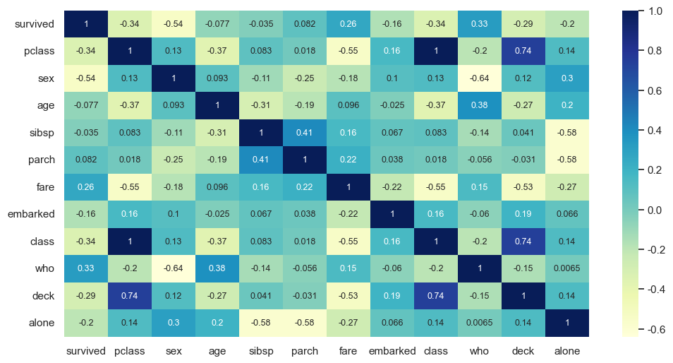

```python
sns.heatmap(titanic_cp_corr, annot=True, cmap="YlGnBu", annot_kws={"size": 9})
plt.show()
```

## 4. pairplot

[pairplot 도큐먼트](https://seaborn.pydata.org/generated/seaborn.pairplot.html?highlight=pairplot#seaborn.pairplot)

- pairplot은 그리도(grid) 형태로 각 **집합의 조합에 대해 히스토그램과 분포도**를 그림
- 변수들 간의 산점도와 히스토그램을 표시하여 변수들 간의 상관관계와 분포를 시각화하는 데 사용함
- 또한, 숫자형 column에 대해서만 그려줌

```python
file_path = "datas/sns_tips.csv"
tips = pd.read_csv(file_path)
tips.head()
```

|  | total_bill | tip | gender | smoker | day | time | size |
| --- | --- | --- | --- | --- | --- | --- | --- |
| 0 | 16.99 | 1.01 | Female | No | Sun | Dinner | 2 |
| 1 | 10.34 | 1.66 | Male | No | Sun | Dinner | 3 |
| 2 | 21.01 | 3.50 | Male | No | Sun | Dinner | 3 |
| 3 | 23.68 | 3.31 | Male | No | Sun | Dinner | 2 |
| 4 | 24.59 | 3.61 | Female | No | Sun | Dinner | 4 |

### 4-1. 기본 pairplot 그리기

- 다변량 데이터셋에서 변수들 간의 관계를 탐색하고 시각화하기 위해 활용
- 중소 규모의 다변량 데이터셋에서 변수들 간의 상관관계와 분포를 빠르게 시각화하고 파악하는 데 유용
- 주로 다음과 같은 상황에서 많이 사용
  - 변수들 간의 상관관계 파악 : 데이터셋의 모든 변수 쌍에 대한 산점도를 생성하므로, 변수들 간의 선형 또는 비선형 상관관계를 파악하는 데 도움이 됨
  - 변수들의 분포 비교 : 변수들의 분포 형태, 이상치 여부, 분산 등을 비교하고 분포의 차이를 시각적으로 파악
  - 데이터셋 탐색: 데이터셋을 처음 탐색할 때 유용, 데이터셋의 변수들 간의 관계를 한눈에 파악할 수 있으며, 변수들의 분포를 확인하여 데이터셋의 특징과 패턴을 이해하는 데 도움

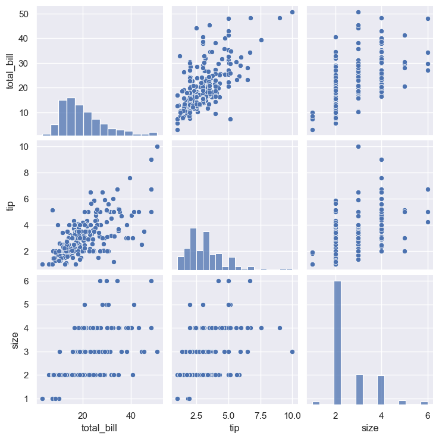

```python
sns.pairplot(tips)
plt.show()
```

### 4-2. hue 옵션으로 특성 구분

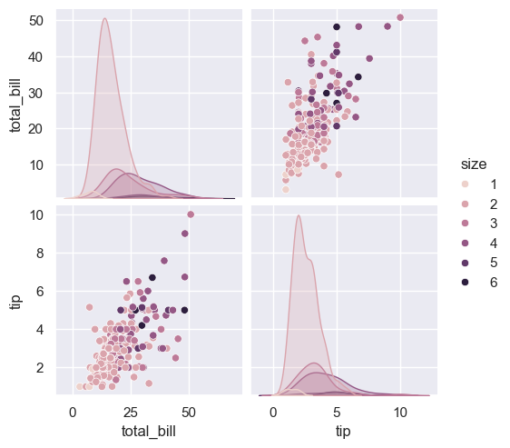

```python
sns.pairplot(tips, hue='size')
plt.show()
```

### 4-3. 컬러 팔레트 적용

예) sns.pairplot(tips, hue='size', palette="rainbow") palette="rainbow" 에서 rainbow 대신 사용가능한 값

- deep: 강렬한 색조의 색상 팔레트로, 주로 분류 작업에 사용
- muted: 조화로운 색상 팔레트로, 시각화를 부드럽게 만들어줌
- bright: 밝은 색상 팔레트로, 시각적으로 눈에 띄게 만들어줌
- pastel: 연한 색조의 색상 팔레트로, 부드럽고 상쾌한 시각화를 만들어줌
- dark: 어두운 색상 팔레트로, 대비를 강조하여 시각화를 선명하게 만들어줌
- colorblind: 색각(색상 감각) 이상을 고려한 색상 팔레트로, 구분하기 쉬운 색조를 사용하여 시각적 접근성을 향상시킴

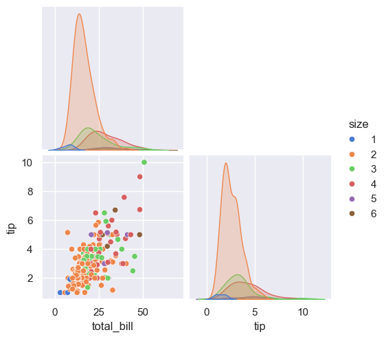

```python
# corner=True : 한쪽만 보기
sns.pairplot(tips, hue='size', palette="muted", corner=True)
plt.show()
```

### 4-4. 그리드의 높이

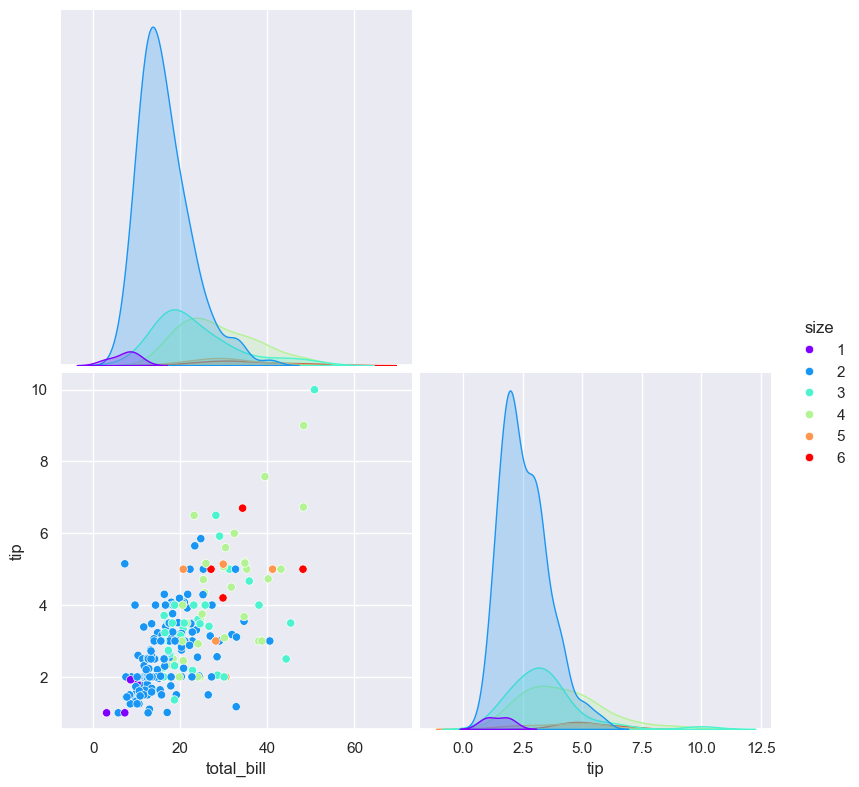

```python
sns.pairplot(tips, hue='size', palette="rainbow", height=4, corner=True)
plt.show()
```

## 5. violinplot

바이올린처럼 생긴 violinplot

column에 대한 **데이터의 비교 분포도**를 확인할 수 있음

[violinplot 도큐먼트](https://seaborn.pydata.org/generated/seaborn.violinplot.html)

### 5-1. 기본 violinplot 그리기

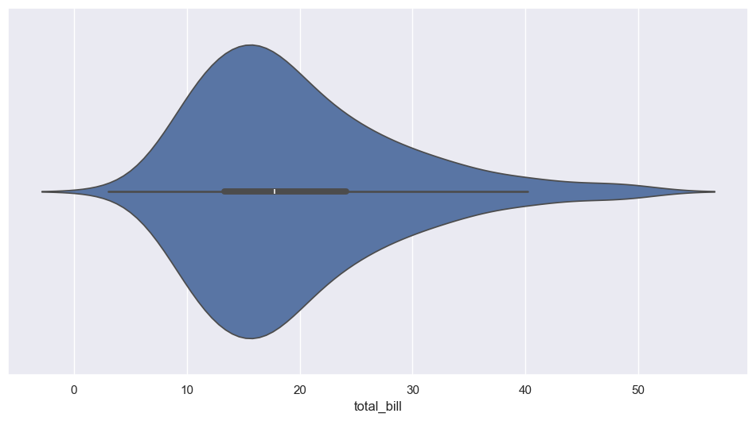

```python
sns.violinplot(x=tips["total_bill"])
plt.show()
```

### 5-2. 비교 분포 확인

x, y축을 지정해줌으로썬 바이올린을 분할하여 **비교 분포**를 볼 수 있습니다.

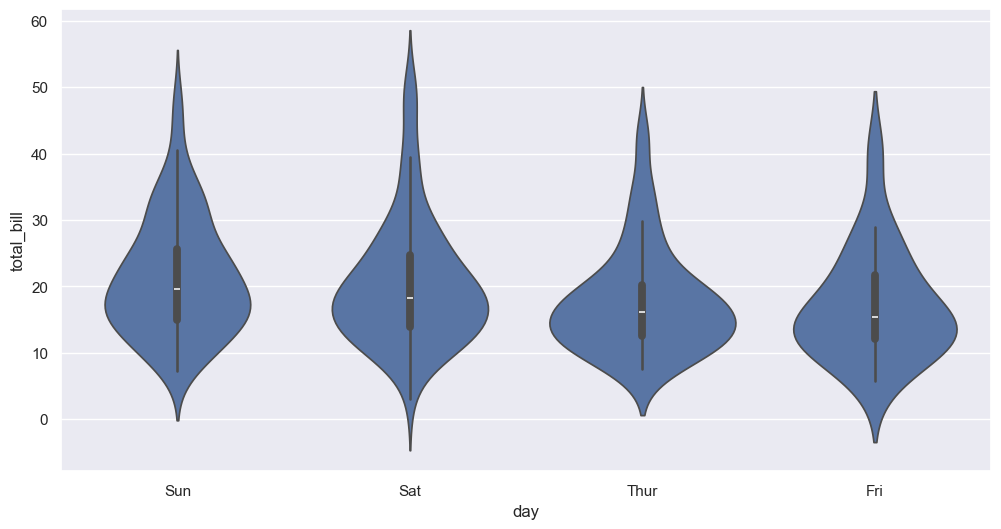

```python
sns.violinplot(data=tips, x="day", y="total_bill")
plt.show()
```

### 5-3. 가로로 뉘인 violinplot

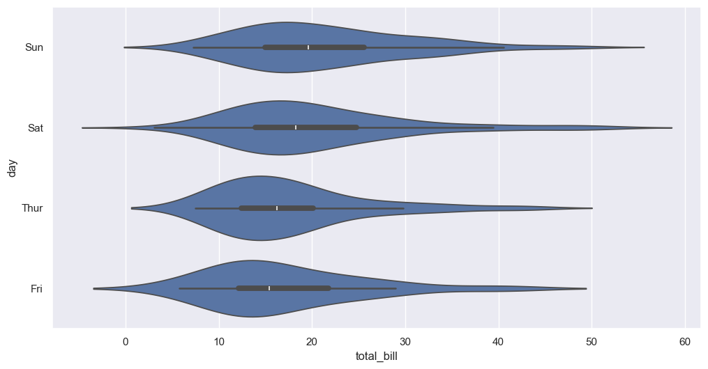

```python
sns.violinplot(data=tips, y="day", x="total_bill")
plt.show()
```

### 5-4. hue 옵션으로 분포 비교

사실 hue 옵션을 사용하지 않으면 바이올린이 대칭이기 때문에 비교 분포의 큰 의미는 없습니다.

하지만, hue 옵션을 주면, **단일 column에 대한 바이올린 모양의 비교**를 할 수 있습니다.

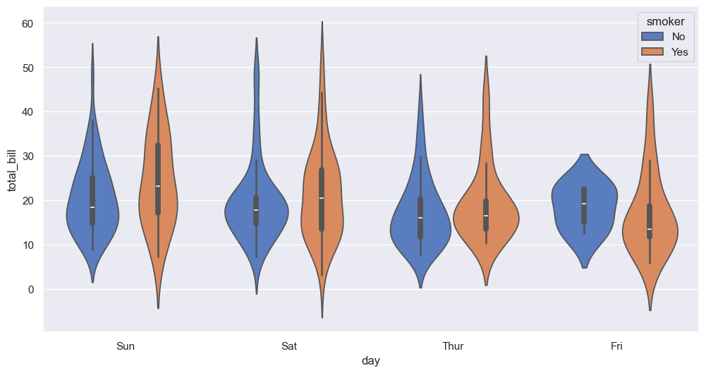

```python
sns.violinplot(data=tips, x="day", y="total_bill", hue="smoker",palette="muted")
plt.show()
```

### 5-5. split 옵션으로 바이올린을 합쳐서 볼 수 있음

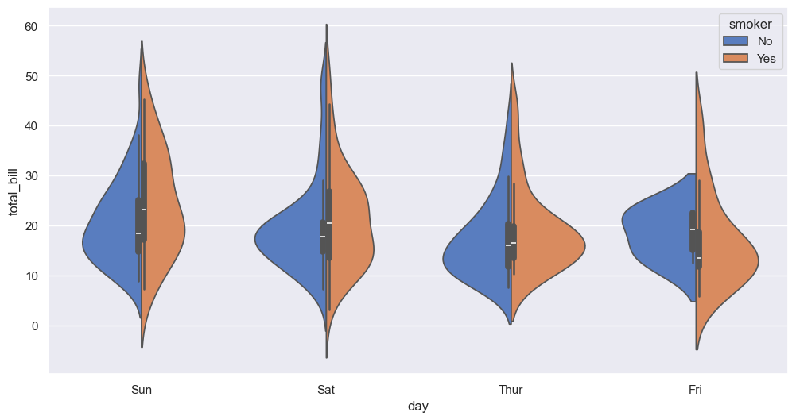

```python
sns.violinplot(data=tips, x="day", y="total_bill", hue="smoker", palette="muted", split=True)
plt.show()
```

### 5-6 violinplot과 stripplot 함께 적용

- violinplot : 연속형 변수의 분포를 바이올린 형태의 그래프로 시각화, 중앙값, 분위수, 이상치등 표현
- stripplot : 주어진 변수에 대한 범주형 데이터의 분포를 점으로 표시하는 그래프

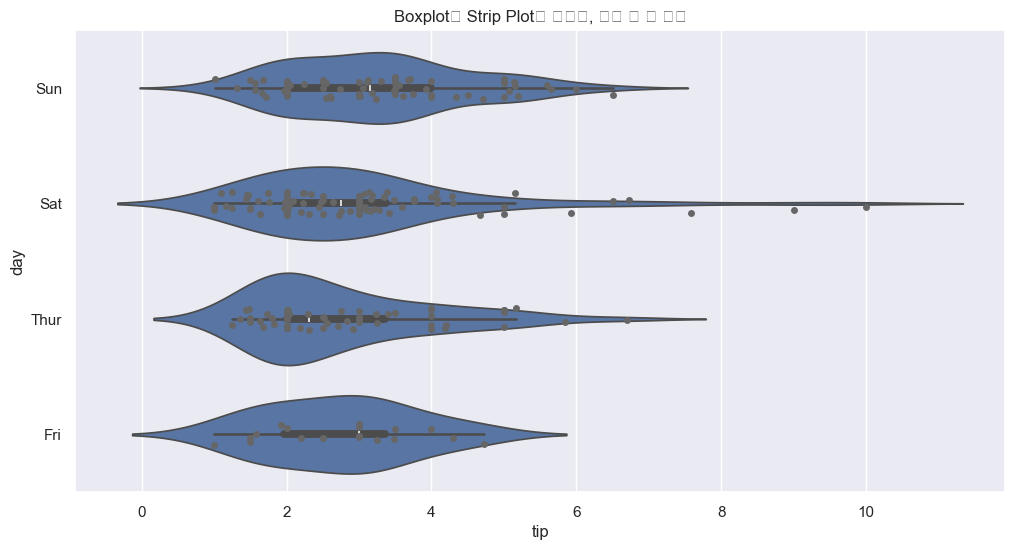

```python
plt.title("Boxplot과 Strip Plot로 표현한, 요일 별 팁 범위")
# sns.boxplot(data=tips, x="tip", y="day", whis=np.inf)
sns.violinplot(data=tips, x="tip", y="day")
sns.stripplot(data=tips, x="tip", y="day", jitter=True, color="0.4")
plt.show()
```

## 6. lmplot

`lmplot`은 column 간의 **선형 회귀 모델(linear regression model)을 시각화하는데 용이한 차트**

또한, **outlier**도 같이 짐작해 볼 수 있음

[lmplot 도큐먼트](https://seaborn.pydata.org/generated/seaborn.lmplot.html)

### 6-1. 기본 lmplot

- 신뢰구간 : ci int in [0, 100] 또는 None, ci=95(default)

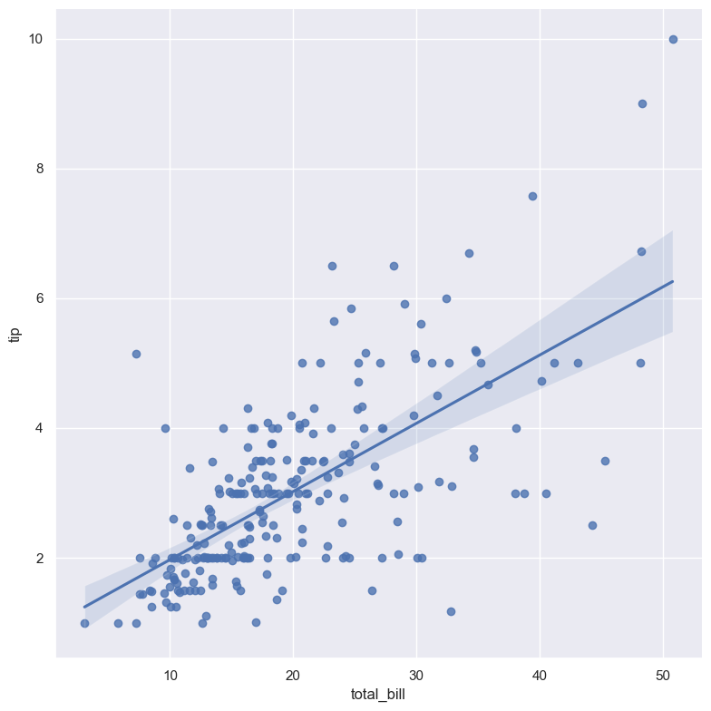

```python
sns.lmplot(data=tips, x="total_bill", y="tip", height=8)
plt.show()
```

### 6-2. hue 옵션으로 다중 선형관계 그리기

아래의 그래프를 통하여 비흡연자가, 흡연자 대비 좀 더 **가파른 선형관계**를 가지는 것을 볼 수 있습니다.

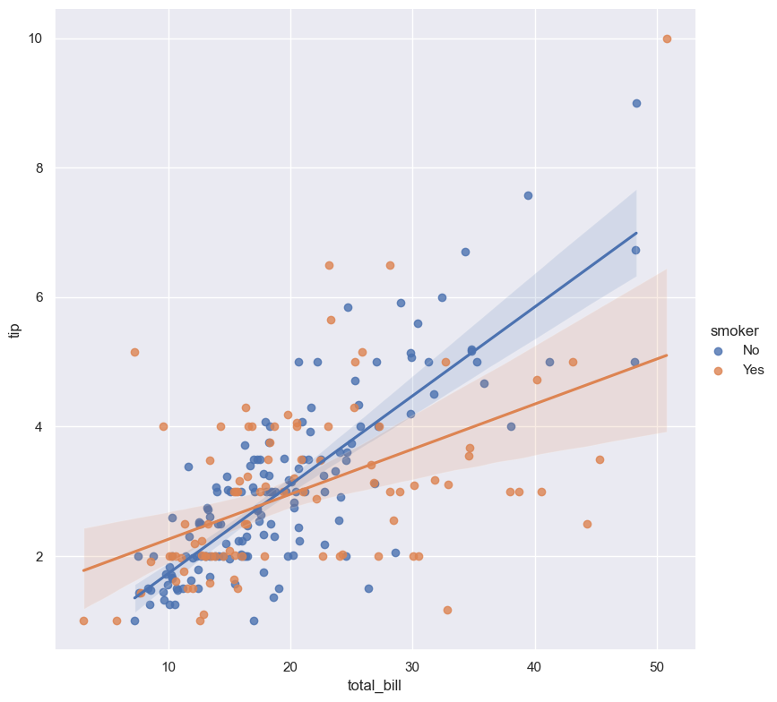

```python
sns.lmplot(data=tips, x="total_bill", y="tip", hue="smoker", height=8)
plt.show()
```

### 6-3. col 옵션을 추가하여 그래프를 별도로 그려볼 수 있음

또한, `col_wrap`으로 한 줄에 표기할 column의 갯수를 명시할 수 있음

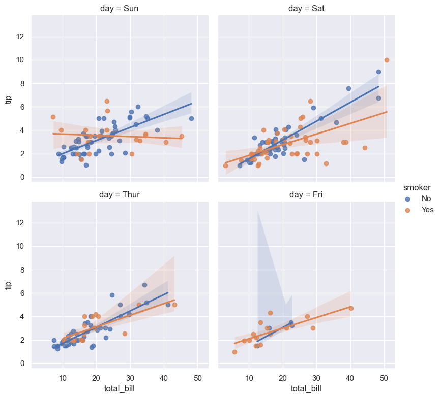

```python
sns.lmplot(data=tips, x='total_bill', y='tip', hue='smoker', col='day', col_wrap=2, height=4)
plt.show()
```

## 7. relplot

두 column간 상관관계를 보지만 `lmplot`처럼 선형관계를 따로 그려주지는 않습니다.

[relplot 도큐먼트](https://seaborn.pydata.org/generated/seaborn.relplot.html?highlight=relplot#seaborn.relplot)

### 7-1. 기본 relplot

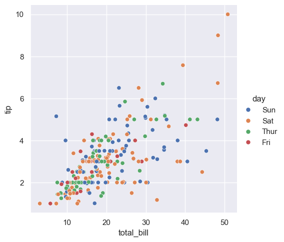

```python
sns.relplot(x="total_bill", y="tip", hue="day", data=tips)
plt.show()
```

### 7-2. col 옵션으로 그래프 분할

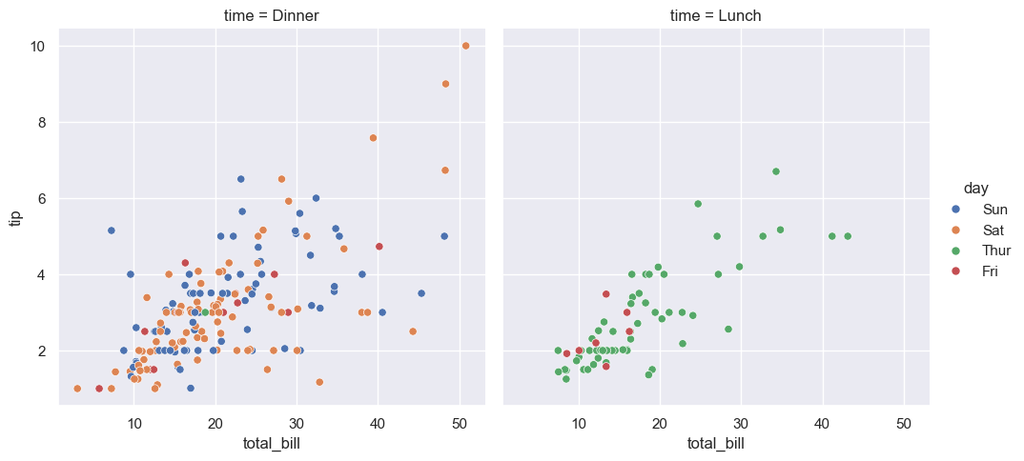

```python
sns.relplot(x="total_bill", y="tip", hue="day", col="time", data=tips)
plt.show()
```

### 7-3. row와 column에 표기할 데이터 column 선택

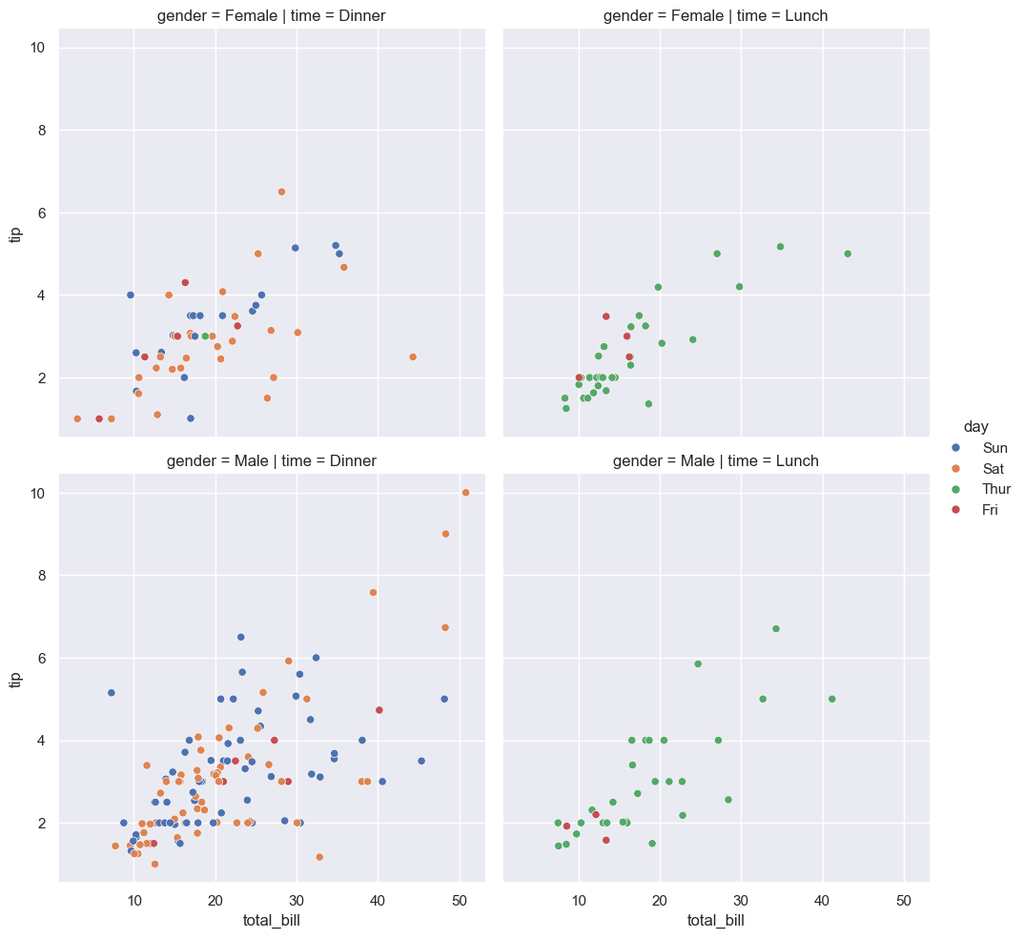

```python
sns.relplot(x="total_bill", y="tip", hue="day", row="gender", col="time", data=tips)
plt.show()
```

### 7-4. 컬러 팔레트 적용

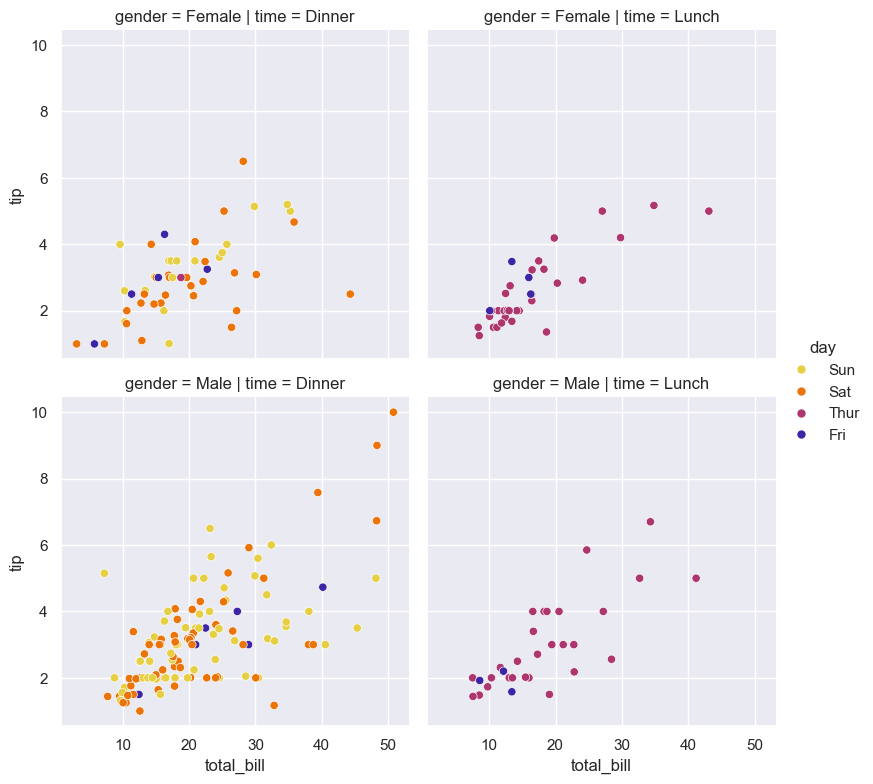

```python
sns.relplot(data=tips, x="total_bill", y="tip", hue="day", row="gender", col="time", palette="CMRmap_r", height=4)
plt.show()
```

## 8. jointplot

scatter(산점도)와 histogram(분포)을 동시에 그려줌

**숫자형 데이터만 표현 가능함**

[jointplot 도큐먼트](https://seaborn.pydata.org/generated/seaborn.jointplot.html?highlight=jointplot#seaborn.jointplot)

### 8-1. 기본 jointplot 그리기

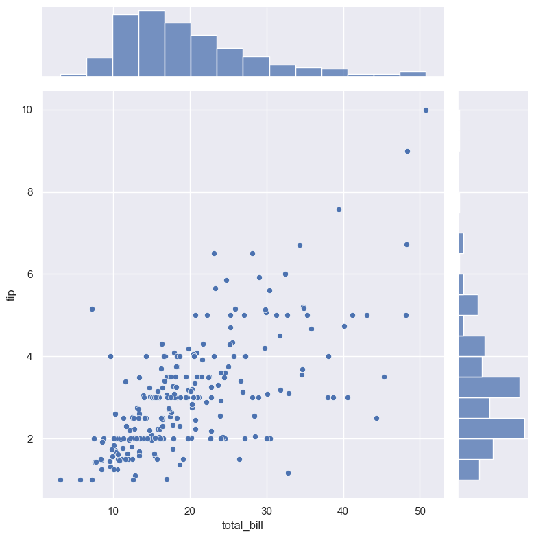

```python
sns.jointplot(data=tips, x="total_bill", y="tip", height=8)
plt.show()
```